# Use deep learning for image classification

This Python notebook shows you how to use [deep learning](https://en.wikipedia.org/wiki/Deep_learning) to build a classification model that maps images of single digit numbers to their corresponding numeric representations.

This notebook is adapted from the deep learning tutorial that describes the important deep learning concepts and includes code snippets at http://www.pyimagesearch.com/2014/09/22/getting-started-deep-learning-python/.

This notebook runs on Python 2 with Spark 2.0.

1. Load libraries
2. Access data
3. Train the pattern recognition model
4. Summary

[figure not shown]

## Load libraries

If you haven't already installed it, run the following cell to install the `nolearn` deep learning Python library in your notebook environment. Then, import the the libraries that you will be using for this notebook.

```python
!pip install --user nolearn
```

```python
import warnings
warnings.filterwarnings("ignore")
from sklearn.cross_validation import train_test_split
from sklearn.metrics import classification_report
from sklearn import datasets
from nolearn.dbn import DBN
import numpy as np
import matplotlib.pyplot as plt
import matplotlib.image as mpimg
%matplotlib inline
```

```
gnumpy: failed to import cudamat. Using npmat instead. No GPU will be used.
```

## Access data

MNIST is a database of handwritten numbers. Because it uses real-world data, it is an ideal database for training neural networks and machine learning tools that use pattern recognition.

Run the following cell to get the MNIST data set of images of handwritten numbers:

```python
from tensorflow.examples.tutorials.mnist import input_data
mnist = input_data.read_data_sets("MNIST_data/")
```

```
Extracting MNIST_data/train-images-idx3-ubyte.gz
Extracting MNIST_data/train-labels-idx1-ubyte.gz
Extracting MNIST_data/t10k-images-idx3-ubyte.gz
Extracting MNIST_data/t10k-labels-idx1-ubyte.gz
```

```python
mnist_images = mnist.train.images
mnist_labels = mnist.train.labels
```

Then split the images into training and testing data sets:

```python
trX, teX, trY, teY = train_test_split(mnist_images, mnist_labels.astype("int0"), test_size = 0.33)
print "Number of images for training:", trX.shape[0]
print "Number of images used for testing:", trY.shape[0]
pix = int(np.sqrt(teX.shape[1]))
print "Each image is:", pix, "by", pix, "pixels"
```

[output not shown]

## Train the pattern recognition model

Run the following cell to train the DBN on handwritten digits. For details on the parameters used in the function, see http://www.pyimagesearch.com/2014/09/22/getting-started-deep-learning-python/.

```python
dbn = DBN(
    [trX.shape[1], 300, 10],
    learn_rates = 0.3,
    learn_rate_decays = 0.9,
    epochs = 10,
    verbose = 1) # set verbose to 0 for not printing output
dbn.fit(trX, trY)
```

```
1%
```

```
[DBN] fitting X.shape=(36850, 784)
[DBN] layers [784, 300, 10]
[DBN] Fine-tune...
```

```
100%
```

```
Epoch 1:
  loss 0.287557810688
  err  0.0839402173913
  (0:00:06)
```

```
100%
```

```
Epoch 2:
  loss 0.174527729877
  err  0.0496739130435
  (0:00:06)
```

```
100%
```

```
Epoch 3:
  loss 0.119425166539
  err  0.0354891304348
  (0:00:06)
```

```
100%
```

```
Epoch 4:
  loss 0.0967299589699
  err  0.0289130434783
  (0:00:06)
```

```
100%
```

```
Epoch 5:
  loss 0.0687037632745
  err  0.0215489130435
  (0:00:06)
```

```
100%
```

```
Epoch 6:
  loss 0.0528241128048
  err  0.0166847826087
  (0:00:06)
```

```
100%
```

```
Epoch 7:
  loss 0.0352837480584
  err  0.0115760869565
  (0:00:06)
```

```
100%
```

```
Epoch 8:
  loss 0.0251386535895
  err  0.00790760869565
  (0:00:06)
```

```
100%
```

```
Epoch 9:
  loss 0.0173274412917
  err  0.00489130434783
  (0:00:06)
```

```
100%
```

```
Epoch 10:
  loss 0.0143236604552
  err  0.00380434782609
  (0:00:06)
```

Then evaluate the the quality of the predictions for each digit:

```python
preds = dbn.predict(teX)
print classification_report(teY, preds)
```

```
             precision    recall  f1-score   support

          0       0.98      0.99      0.98      1811
          1       0.99      0.99      0.99      2049
          2       0.97      0.97      0.97      1839
          3       0.98      0.95      0.97      1895
          4       0.98      0.98      0.98      1745
          5       0.98      0.97      0.97      1641
          6       0.98      0.99      0.98      1766
          7       0.97      0.98      0.98      1862
          8       0.95      0.97      0.96      1711
          9       0.97      0.97      0.97      1831

avg / total       0.98      0.98      0.98     18150
```

Define a function that randomly selects a few of the test images and their predictions:

```
Actual digit is 7 predicted 7
```

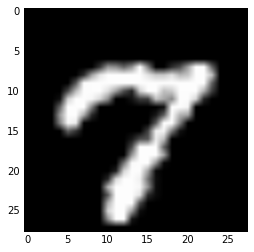

```python
def randIm():
    i = np.random.choice(np.arange(0, len(teY)), size = (1,))
    pred = dbn.predict(np.atleast_2d(teX[i]))
    image = (teX[i] * 255).reshape((28, 28)).astype("uint8")
    # show the prediction
    print "Actual digit is", teY[i][0], "predicted", pred[0]
    imgplot = plt.imshow(image)
    imgplot.set_cmap('gray')

randIm()
```

Run this function several times to see randomly picked examples from the test data set:

```
Actual digit is 5 predicted 5
```

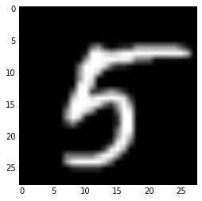

```python
randIm()
```

```
Actual digit is 7 predicted 7
```

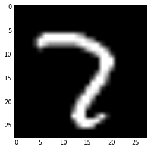

```python
randIm()
```

## Summary

In this Python notebook, you learned how to access the MNIST database that contains sample handwritten numbers. You learned to train the DBN solver to recognize handwritten single digit numbers and evaluate the predicted numeric output.

## Authors

**Jorge Castañón** is a data scientist at IBM Analytics, specializing in machine learning and text analytics using Apache Spark and Hadoop.

Some of the code used in this notebook was contributed by **Adrian Rosebrook**, entrepreneur and Chief PyImageSearcher at www.pyimagesearch.com.

Copyright © IBM Corp. 2016. This notebook and its source code are released under the terms of the MIT License.